# Project2

Kevin Francis

4/12/2021

# Data Description

The data I choose describes the housing prices in Melbourne. I am interested in looking for a relationship between a property sale price and the year built, property size, property type, and suburb. Below the data is being filtered and presented. I am only interested in looking specific suburbs and properties larger that 50 square meters. The data can be looked at in the table below.

```r
# Disabling scientific notation for this chunk. No numbers are that large
options(scipen=999)

#Reading in the data
data <- read.csv("Melbourne_housing_FULL.csv") %>%
  dplyr::select(Regionname, Type, YearBuilt, BuildingArea, Price,
                Method)

#Dropping rows with incomplete data
data <- na.omit(data)

# Filtering to only look at the properties I am interested in
# Homes above 50 square meters and less than 1500 square meters
data <- data[!(data$BuildingArea<=50 | data$BuildingArea>=1500),]
# Home built only after 1900
data <- data[(data$YearBuilt>=1900),]
# Only homes that have sold
data <- data[(data$Method=='S'),]
# Filtering to only look at two suburbs
data <- data[(data$Regionname=='Northern Metropolitan') | (data$Regionname=='Southern Metropolitan')  ,]

# Renaming categorical variables
data <- data %>%
  mutate(Type = replace(Type, Type == 'u', 'Apartment'))
data <- data %>%
  mutate(Type = replace(Type, Type == 't', 'Townhouse'))
data <- data %>%
  mutate(Type = replace(Type, Type == 'h', 'House'))

#Creating a dummy variable for the housing type and region variables
data <- dummy_cols(data, select_columns = c('Type', 'Regionname'))

#Displaying the data
datatable(data[,1:5], class = 'display')
```

|  | Regionname | Type | YearBuilt | BuildingArea | Price |
| --- | --- | --- | --- | --- | --- |
| 1 | Southern Metropolitan | House | 1940 | 465 | 6600000 |
| 2 | Southern Metropolitan | House | 1920 | 308 | 6400000 |
| 3 | Southern Metropolitan | House | 1930 | 435 | 6300000 |
| 4 | Southern Metropolitan | House | 2000 | 342 | 6250000 |
| 5 | Southern Metropolitan | House | 1982 | 340 | 6125000 |
| 6 | Southern Metropolitan | House | 2011 | 638 | 5770000 |
| 7 | Southern Metropolitan | House | 1935 | 516 | 5525000 |
| 8 | Southern Metropolitan | House | 1971 | 300 | 5510000 |
| 9 | Southern Metropolitan | House | 1923 | 332 | 5500000 |
| 10 | Southern Metropolitan | House | 1920 | 453 | 5450000 |

[output cut: 3408 more lines]

```r
# Used for summary statistics
data$TypeDummy <- as.numeric(as.factor(data$Type))
data$RegionDummy <- as.numeric(as.factor(data$Regionname))

# Filtering to only look at the suburbs I am interested in
data <- data %>%
  rename(
     NorthMetro = `Regionname_Northern Metropolitan`,
    SouthMetro = `Regionname_Southern Metropolitan`
    )

#Generating summary statistics for the data
YearBuilt_summ <- data %>%
  summarise(mean = mean(YearBuilt), sd = sd(YearBuilt), median = median(YearBuilt), IQR = IQR(YearBuilt), mode = getmode(YearBuilt), sampeSize = length(YearBuilt))
building_summ <- data %>%
  summarise(mean = mean(BuildingArea), sd = sd(BuildingArea), median = median(BuildingArea),   IQR = IQR(BuildingArea), mode = getmode(BuildingArea), sampeSize = length(BuildingArea))
price_summ <- data %>%
  summarise(mean = mean(Price), sd = sd(Price), median = median(Price),   IQR = IQR(Price), mode = getmode(Price), sampeSize = length(Price))
type_summ <- data %>%
  summarise(mean = mean(TypeDummy), sd = sd(TypeDummy), median = median(TypeDummy),   IQR = IQR(TypeDummy), mode = getmode(TypeDummy), sampeSize = length(TypeDummy))
region_summ <- data %>%
  summarise(mean = mean(RegionDummy), sd = sd(RegionDummy), median = median(RegionDummy),   IQR = IQR(RegionDummy), mode = getmode(RegionDummy), sampeSize = length(RegionDummy))

#Neatly displaying the summary statistics
cols <- c('Housing Type', 'YearBuilt', 'Building Size', 'Region', 'Price')
col.Variable <- data.frame(cols)
summ1 <- rbind(type_summ, YearBuilt_summ, building_summ, region_summ, price_summ)
summ <- cbind2(col.Variable, summ1)
knitr::kable(summ, align='lccrr', caption = 'Mean, Standard Deviation, Median, and IQR of the data', col.names = c('Variable', 'Mean', 'Standard Deviation', 'Median', 'IQR', 'Mode', 'Sample Size'))
```

Mean, Standard Deviation, Median, and IQR of the data

| Variable | Mean | Standard Deviation | Median | IQR | Mode | Sample Size |
| --- | --- | --- | --- | --- | --- | --- |
| Housing Type | 1.910181 | 0.5348345 | 2 | 0 | 2 | 3418 |
| YearBuilt | 1965.744002 | 35.1874990 | 1970 | 60 | 1960 | 3418 |
| Building Size | 146.327899 | 77.5760746 | 129 | 74 | 100 | 3418 |
| Region | 1.476302 | 0.4995112 | 1 | 1 | 1 | 3418 |
| Price | 1161733.726156 | 718000.7441551 | 936500 | 774875 | 600000 | 3418 |

This is a key to the summary statistics table for the categorical predictors. Dummy variables were used for the summary statistics.

[output not shown]

## Plots

Now lets look at some plots to explore the data. These will help to show the minimums, maximums, distributions, outliers, and more for the predictors. These can also be a good starting point if the initial results are unexpected.

#### Distribution Plots

Below are distribution plots for each predictor.

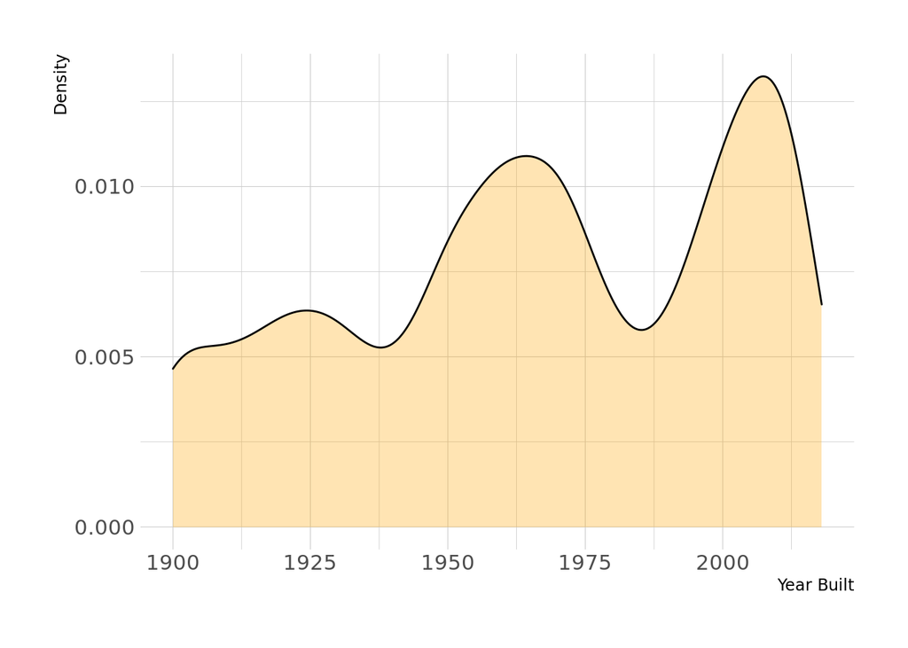

```r
ggplot(data=data, aes(x=data$YearBuilt)) +
    geom_density(alpha=.3, fill='orange') +
    theme_ipsum_es() +
    xlab('Year Built') +
    ylab('Density')
```

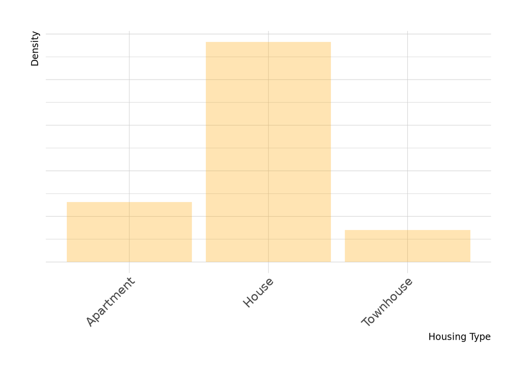

```r
ggplot(data=data, aes(x=factor(data$TypeDummy))) +
    geom_bar(alpha=.3, fill='orange') +
    theme_ipsum_es() +
    xlab('Housing Type') +
    ylab('Density') +
    theme(axis.text.y=element_blank(), axis.text.x = element_text(angle = 45, hjust = 1)) +
    scale_x_discrete(labels = c('Apartment','House','Townhouse'))
```

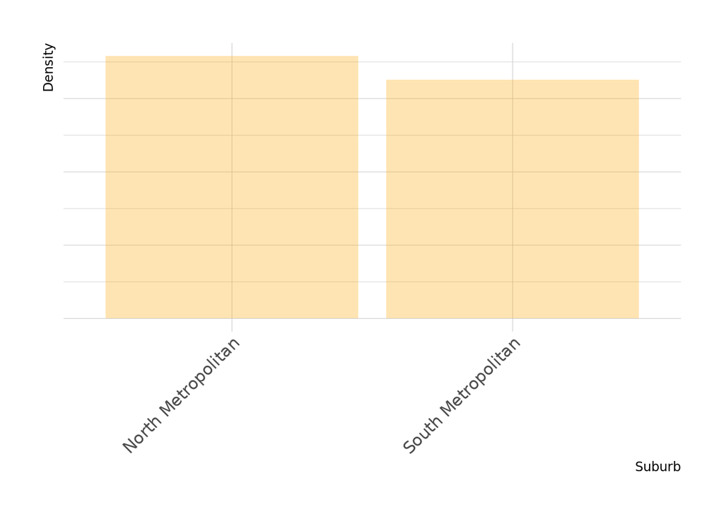

```r
ggplot(data=data, aes(x=factor(data$RegionDummy))) +
    geom_bar(alpha=.3, fill='orange') +
    theme_ipsum_es() +
    xlab('Suburb') +
    ylab('Density') +
    theme(axis.text.y=element_blank(), axis.text.x = element_text(angle = 45, hjust = 1)) +
    scale_x_discrete(labels = c('North Metropolitan','South Metropolitan'))
```

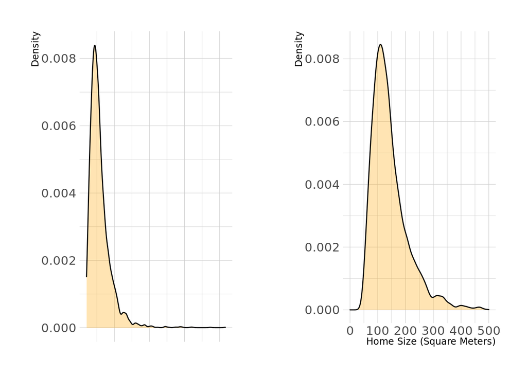

```r
# Make another plot to not show outliers
density <- ggplot(data=data, aes(x=data$BuildingArea)) +
    geom_density(alpha=.3, fill='orange') +
    theme_ipsum_es() +
    xlab('Home Size (Square Meters)') +
    ylab('Density') +
    theme(axis.title.x=element_blank(), axis.text.x=element_blank(), axis.ticks.x=element_blank())

density_zoom <- ggplot(data=data, aes(x=data$BuildingArea)) +
    geom_density(alpha=.3, fill='orange') +
    theme_ipsum_es() +
    xlab('Home Size (Square Meters)') +
    ylab('Density') +
    xlim(0, 500)


plot_grid(density, density_zoom)
```

For the plots above I have zoomed in so that the distribution majority is easier to read. This is also done for a scatter plot down below because of an outlier.

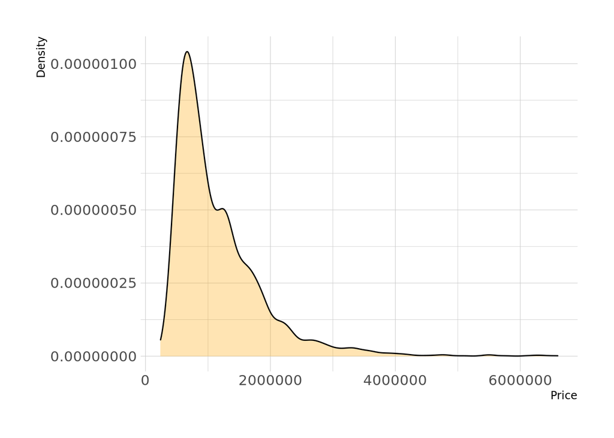

```r
ggplot(data=data, aes(x=data$Price)) +
    geom_density(alpha=.3, fill='orange') +
    theme_ipsum_es() +
    xlab('Price') +
    ylab('Density')
```

#### Scatter Plots

Below are scatter plots that show each predictor vs the sale price.

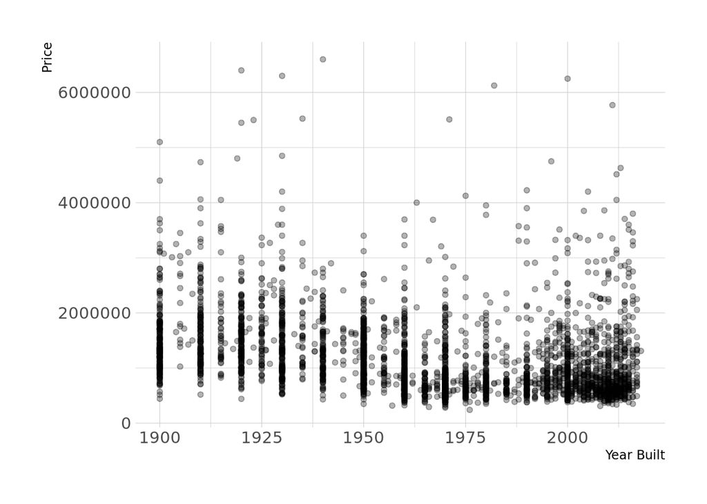

```r
ggplot(data=data, aes(x=data$YearBuilt, y=data$Price)) +
    geom_point(alpha=.3) +
    theme_ipsum_es() +
    xlab('Year Built') +
    ylab('Price')
```

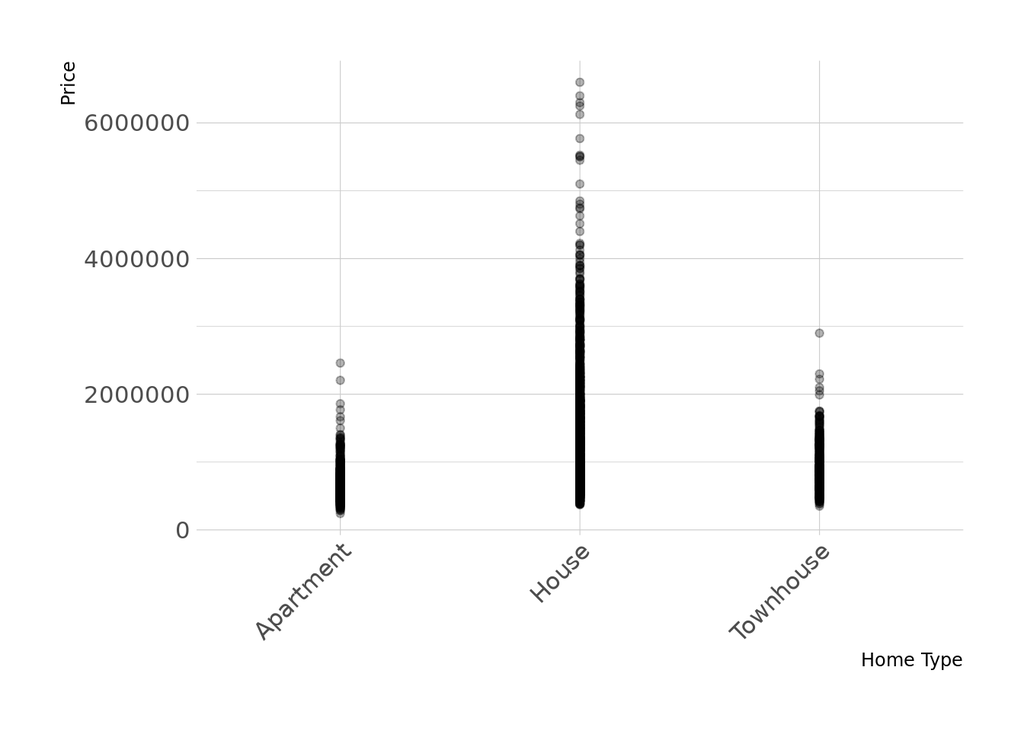

```r
ggplot(data=data, aes(x=data$Type, y=data$Price)) +
    geom_point(alpha=.3) +
    theme_ipsum_es() +
    xlab('Home Type') +
    ylab('Price') +
    theme(axis.text.x = element_text(angle = 45, hjust = 1))
```

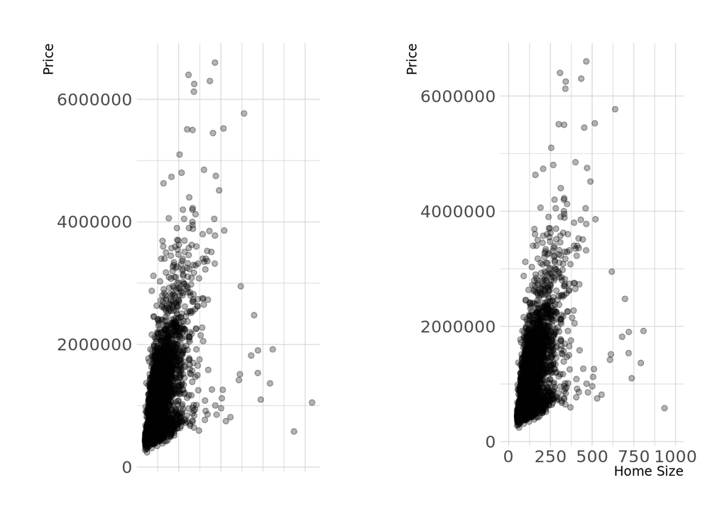

```r
scatter <- ggplot(data=data, aes(x=data$BuildingArea, y=data$Price)) +
    geom_point(alpha=.3) +
    theme_ipsum_es() +
    xlab('Home Size') +
    ylab('Price') +
    theme(axis.title.x=element_blank(), axis.text.x=element_blank(), axis.ticks.x=element_blank())

scatter_zoom <- ggplot(data=data, aes(x=data$BuildingArea, y=data$Price)) +
    geom_point(alpha=.3) +
    theme_ipsum_es() +
    xlab('Home Size') +
    ylab('Price') +
    xlim(0, 1000)

plot_grid(scatter, scatter_zoom)
```

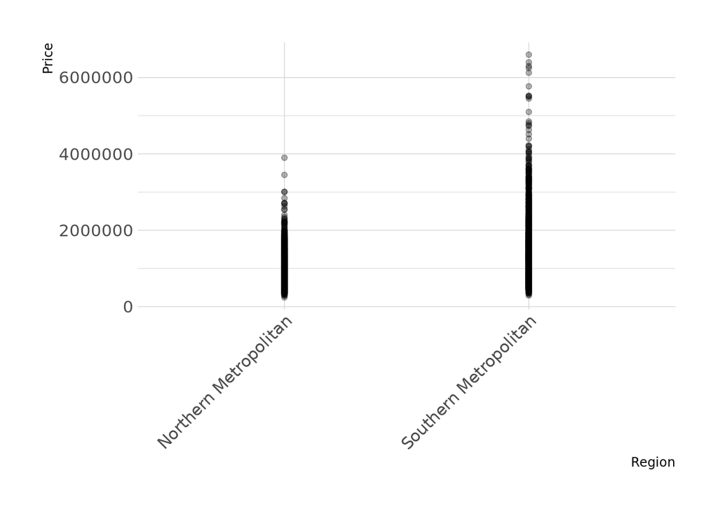

```r
ggplot(data=data, aes(x=data$Regionname, y=data$Price)) +
    geom_point(alpha=.3) +
    theme_ipsum_es() +
    xlab('Region') +
    ylab('Price') +
    theme(axis.text.x = element_text(angle = 45, hjust = 1))
```

#### Additional Plots

Here are some plots to help see relationships between some of the variables.

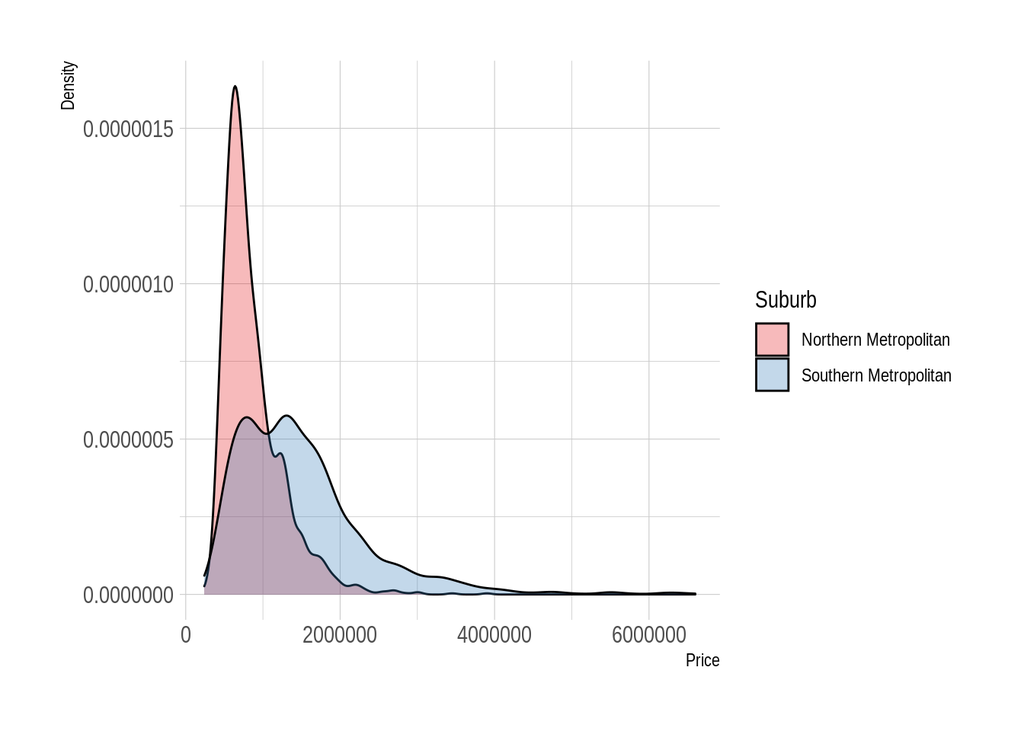

```r
ggplot(data=data, aes(x=data$Price, group=data$Regionname, fill=data$Regionname)) +
    geom_density(alpha=.3) +
    theme_ipsum() +
    xlab('Price') +
    ylab('Density') + labs(fill = 'Suburb') +
    scale_fill_brewer(palette="Set1")
```

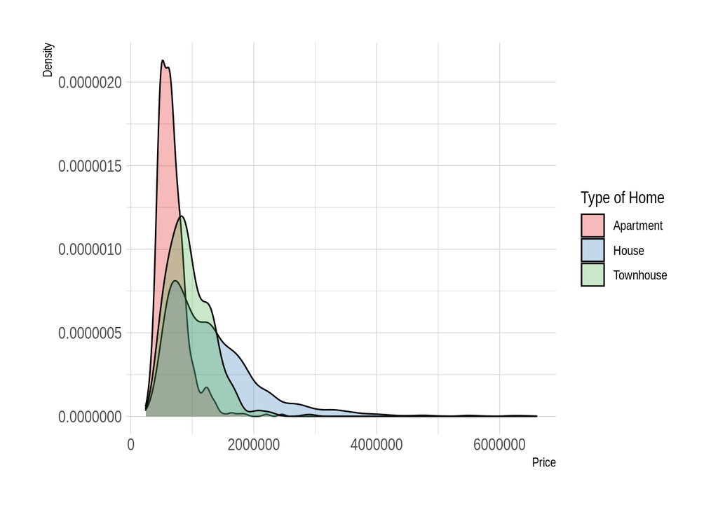

```r
ggplot(data=data, aes(x=data$Price, group=data$Type, fill=data$Type)) +
    geom_density(alpha=.3) +
    theme_ipsum() +
    xlab('Price') +
    ylab('Density') + labs(fill = 'Type of Home') +
    scale_fill_brewer(palette="Set1")
```

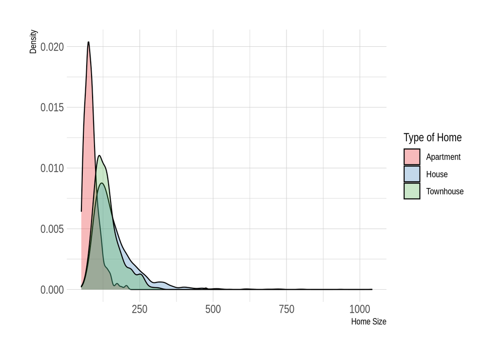

```r
ggplot(data=data, aes(x=data$BuildingArea, group=data$Type, fill=data$Type)) +
    geom_density(alpha=.3) +
    theme_ipsum() +
    xlab('Home Size') +
    ylab('Density') + labs(fill = 'Type of Home') +
    scale_fill_brewer(palette="Set1")
```

# Regression Model

Now lets create a regression model. The predictors are the same as above, but the model will also include two interactions I am interested in looking at. Note that apartments and south metro are the reference groups for the two categorical predictors.

```r
model <- lm(Price ~ YearBuilt+BuildingArea+Type_Townhouse+Type_House+NorthMetro+NorthMetro:Type_Townhouse+NorthMetro:Type_House, data=data)
coef <- coefficients(model)
anova <- anova(model)
summary <- summary(model)
ci <- as_tibble(confint(model, level=0.95))
t <- as_tibble(summary[[4]])
```

```r
#Adding a variable column to table
Variable <- c('Intercept', 'Year Built', 'Home Size', 'Townhouse', 'House', 'North Metro', 'NorthMetro:Townhouse', 'NorthMetro:House')
col.Variable2 <- data.frame(Variable)
summ3 <- cbind2(col.Variable2, t)
knitr::kable(summ3, align='lccrr')
```

| Variable | Estimate | Std. Error | t value | Pr(>\|t\|) |
| --- | --- | --- | --- | --- |
| Intercept | 10911432.148 | 506963.0734 | 21.523130 | 0.0000000 |
| Year Built | -5346.003 | 257.9233 | -20.727104 | 0.0000000 |
| Home Size | 4148.613 | 117.4344 | 35.327074 | 0.0000000 |
| Townhouse | 265131.886 | 41492.9048 | 6.389813 | 0.0000000 |
| House | 596166.085 | 30390.2043 | 19.617048 | 0.0000000 |
| North Metro | -54264.764 | 37157.2885 | -1.460407 | 0.1442704 |
| NorthMetro:Townhouse | -158852.921 | 61651.2978 | -2.576636 | 0.0100184 |
| NorthMetro:House | -642515.762 | 41750.4302 | -15.389440 | 0.0000000 |

The resulting regression model is
$$\hat{Y} = 10911432.15 -5346X_{\mbox{YearBuilt}} + 4148.61X_{\mbox{HomeSize}} + 265131.89X_{\mbox{Townhouse}} \\ + 596166.09X_{\mbox{House}} -54264.76X_{\mbox{NorthMetro}} -158852.92X_{\mbox{NorthMetro:Townhouse}} \\ -642515.76X_{\mbox{NorthMetro:House}}$$

# Test for Significance of Interaction

```r
# Reduced model and summary
red_model <- lm(Price ~ YearBuilt+BuildingArea+Type_Townhouse+Type_House+NorthMetro, data=data)
red_coef <- coefficients(red_model)
red_anova <- anova(red_model)
red_summary <- summary(red_model)
red_ci <- as_tibble(confint(red_model, level=0.95))
red_t <- as_tibble(red_summary[[4]])
int_anova <- anova(red_model, model)
```

**Hypotheses**

$H_0: \beta_1 = \beta_2 =0$ (The interaction should be dropped)  
$H_1: \beta_1 \space or \space \beta_2 \ne 0$ (The interaction should not be dropped)

**Test Statistic**

$F_0 = 141.25$.

*p*-value

$p < 0.0001$.

**Rejection Region**

Reject if $p < \alpha$, where $\alpha=0.05$.

**Conclusion and Interpretation**

Reject $H_0$. There is sufficient evidence to suggest that the interaction is significant and should not be dropped.

# Testing for Dropping two Continuous Predictors

```r
# Reduced model and summary
red_model <- lm(Price ~ Type_Townhouse+Type_House+NorthMetro+NorthMetro:Type_Townhouse+NorthMetro:Type_House, data=data)
red_coef <- coefficients(red_model)
red_anova <- anova(red_model)
red_summary <- summary(red_model)
red_ci <- as_tibble(confint(red_model, level=0.95))
red_t <- as_tibble(red_summary[[4]])
int_anova <- anova(red_model, model)
```

**Hypotheses**

$H_0: \beta_1 = \beta_2 =0$ (The predictors should be dropped)  
$H_1: \beta_1 \space or \space \beta_2 \ne 0$ (The predictors should not be dropped)

**Test Statistic**

$F_0 = 691.19$.

*p*-value

$p < 0.0001$.

**Rejection Region**

Reject if $p < \alpha$, where $\alpha=0.05$.

**Conclusion and Interpretation**

Reject $H_0$. There is sufficient evidence to suggest that the continuous predictors should not be dropped from the model.

# Reconstructed Regression Line

Since all of the above tests showed that none of the tested predictors should not be dropped, the regression line remains the same as the full model above.

# Testing for Significance of Remaining Individual Predictors

#### Test for Year Built

**Hypotheses**

$H_0: \ \beta_2 = 0$  
$H_1: \ \beta_2 \ne 0$

**Test Statistic**

$t_0 = -20.73$.

*p*-value

$p < 0.0001$.

**Rejection Region**

Reject if $p < \alpha$, where $\alpha=0.05$.

**Conclusion and Interpretation**

Reject $H_0$. There is sufficient evidence to suggest that the year the home is built is a significant predictor of sale price.

#### Test for Home Size

**Hypotheses**

$H_0: \ \beta_3 = 0$  
$H_1: \ \beta_3 \ne 0$

**Test Statistic**

$t_0 = 35.33$.

*p*-value

$p < 0.0001$.

**Rejection Region**

Reject if $p < \alpha$, where $\alpha=0.05$.

**Conclusion and Interpretation**

Reject $H_0$. There is sufficient evidence to suggest that the home size is a significant predictor of sale price.

#### Test for Townhouse

**Hypotheses**

$H_0: \ \beta_4 = 0$  
$H_1: \ \beta_4 \ne 0$

**Test Statistic**

$t_0 = 6.39$.

*p*-value

$p < 0.0001$.

**Rejection Region**

Reject if $p < \alpha$, where $\alpha=0.05$.

**Conclusion and Interpretation**

Reject $H_0$. There is sufficient evidence to suggest that the home being a townhouse is a significant predictor of sale price.

#### Test for House

**Hypotheses**

$H_0: \ \beta_5 = 0$  
$H_1: \ \beta_5 \ne 0$

**Test Statistic**

$t_0 = 19.62$.

*p*-value

$p < 0.0001$.

**Rejection Region**

Reject if $p < \alpha$, where $\alpha=0.05$.

**Conclusion and Interpretation**

Reject $H_0$. There is sufficient evidence to suggest that the the home being a house is a significant predictor of sale price.

#### Test for North Metro

**Hypotheses**

$H_0: \ \beta_6 = 0$  
$H_1: \ \beta_6 \ne 0$

**Test Statistic**

$t_0 = -1.46$.

*p*-value

$p = 0.1443$.

**Rejection Region**

Reject if $p < \alpha$, where $\alpha=0.05$.

# Final Model

One predictor was found to not be significant. However, I am going to keep north metro in the model. This is because it is included in higher order effects that were deemed significant. If north metro is removed, then the higher order terms must also be removed.

The final regression model is
$$\hat{Y} = 10911432.15 -5346X_{\mbox{YearBuilt}} + 4148.61X_{\mbox{HomeSize}} + 265131.89X_{\mbox{Townhouse}} \\ + 596166.09X_{\mbox{House}} -54264.76X_{\mbox{NorthMetro}} -158852.92X_{\mbox{NorthMetro:Townhouse}} \\ -642515.76X_{\mbox{NorthMetro:House}}$$

#### Interpretation of Final Model

- For each increase in the year built, the price decreases by 5346 dollars.
- For an increase in the home size, the price increases by 4148.61 dollars.
- If the home is a townhouse, the price is 265131.89 dollars more than an apartment.
- If the home is a house, the price is 596166.09 dollars more than an apartment.
- If the home is located in the north metro, the price decreases by 54264.76 dollars.
- If a townhouse is in the north metro, the price decreases by an additional 158852.92 dollars.
- If a house is in the north metro, the price decreases by an additional 642515.76 dollars.

# Model visualizations

Here are some plots to help visualize the results of the model. Each plot shows a continuous predictor vs price. The original data is shown as a scatter plot, and overlaid is predicted values from the model corresponding to different categorical predictor combinations.

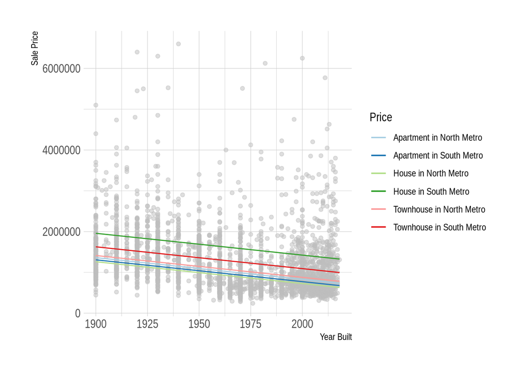

```r
data$pred_price_yearbuilt_townhouse_north <- coef[[1]] + coef[[2]]*(data$YearBuilt) + coef[[3]]*mean(data$BuildingArea) + coef[[4]] + coef[[6]] + coef[[7]]
data$pred_price_yearbuilt_townhouse_south <- coef[[1]] + coef[[2]]*(data$YearBuilt) + coef[[3]]*mean(data$BuildingArea) + coef[[4]]
data$pred_price_yearbuilt_house_south <- coef[[1]] + coef[[2]]*(data$YearBuilt) + coef[[3]]*mean(data$BuildingArea) + coef[[5]]
data$pred_price_yearbuilt_house_north <- coef[[1]] + coef[[2]]*(data$YearBuilt) + coef[[3]]*mean(data$BuildingArea) + coef[[5]] + coef[[6]] + coef[[8]]
data$pred_price_yearbuilt_apa_south <- coef[[1]] + coef[[2]]*(data$YearBuilt) + coef[[3]]*mean(data$BuildingArea)
data$pred_price_yearbuilt_apa_north <- coef[[1]] + coef[[2]]*(data$YearBuilt) + coef[[3]]*mean(data$BuildingArea) + coef[[6]]

ggplot(data=data, aes(x=data$YearBuilt, y=data$Price)) +
    geom_point(alpha=.5, color='gray') +
    theme_ipsum() +
    xlab('Year Built') +
    ylab('Sale Price') +
    geom_line(aes(y=data$pred_price_yearbuilt_townhouse_north, color = "Townhouse in North Metro"), linetype = "solid") +
    geom_line(aes(y=data$pred_price_yearbuilt_townhouse_south, color = "Townhouse in South Metro"), linetype = "solid") +
    geom_line(aes(y=data$pred_price_yearbuilt_house_north, color = "House in North Metro"), linetype = "solid") +
    geom_line(aes(y=data$pred_price_yearbuilt_house_south, color = "House in South Metro"), linetype = "solid") +
    geom_line(aes(y=data$pred_price_yearbuilt_apa_north, color = "Apartment in South Metro"), linetype = "solid") +
    geom_line(aes(y=data$pred_price_yearbuilt_apa_south, color = "Apartment in North Metro"), linetype = "solid") +
    scale_color_brewer(name = "Price", palette="Paired")
```

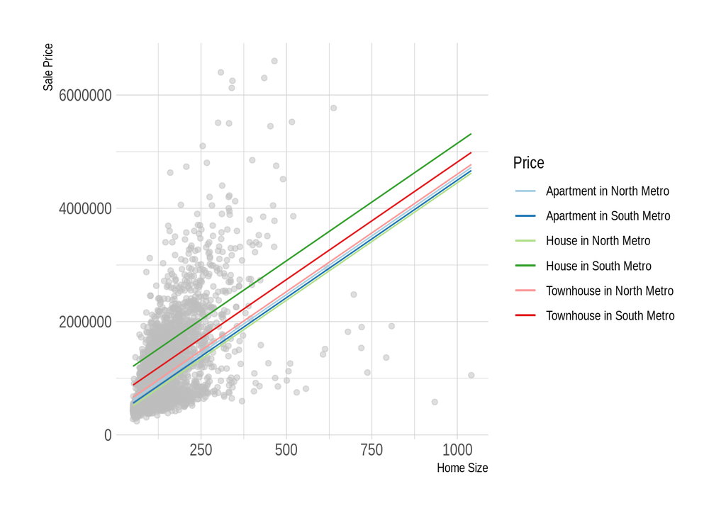

```r
data$pred_price_size_townhouse_north <- coef[[1]] + coef[[2]]*mean(data$YearBuilt) + coef[[3]]*(data$BuildingArea) + coef[[4]] + coef[[6]] + coef[[7]]
data$pred_price_size_townhouse_south <- coef[[1]] + coef[[2]]*mean(data$YearBuilt) + coef[[3]]*(data$BuildingArea) + coef[[4]]
data$pred_price_size_house_south <- coef[[1]] + coef[[2]]*mean(data$YearBuilt) + coef[[3]]*(data$BuildingArea) + coef[[5]]
data$pred_price_size_house_north <- coef[[1]] + coef[[2]]*mean(data$YearBuilt) + coef[[3]]*(data$BuildingArea) + coef[[5]] + coef[[6]] + coef[[8]]
data$pred_price_size_apa_south <- coef[[1]] + coef[[2]]*mean(data$YearBuilt) + coef[[3]]*(data$BuildingArea)
data$pred_price_size_apa_north <- coef[[1]] + coef[[2]]*mean(data$YearBuilt) + coef[[3]]*(data$BuildingArea) + coef[[6]]

ggplot(data=data, aes(x=data$BuildingArea, y=data$Price)) +
    geom_point(alpha=.5, color='gray') +
    theme_ipsum() +
    xlab('Home Size') +
    ylab('Sale Price') +
    geom_line(aes(y=data$pred_price_size_townhouse_north, color = "Townhouse in North Metro"), linetype = "solid") +
    geom_line(aes(y=data$pred_price_size_townhouse_south, color = "Townhouse in South Metro"), linetype = "solid") +
    geom_line(aes(y=data$pred_price_size_house_north, color = "House in North Metro"), linetype = "solid") +
    geom_line(aes(y=data$pred_price_size_house_south, color = "House in South Metro"), linetype = "solid") +
    geom_line(aes(y=data$pred_price_size_apa_north, color = "Apartment in South Metro"), linetype = "solid") +
    geom_line(aes(y=data$pred_price_size_apa_south, color = "Apartment in North Metro"), linetype = "solid") +
    scale_color_brewer(name = "Price", palette="Paired")
```